# 17_ed_variables

Joanna Schroeder

9/18/2020

```r
# function for data profiling
data_profiling <- function(df){
summary_table <- tibble(var = names(df),
       variable_type = map_chr(.x = df, .f = function(col) class(x = col)),
       num_unique = map_int(.x = df, .f = function(col) length(x = unique(x = col))),
       num_missing = map_int(.x = df, .f = function(col) sum(x = is.na(x = col)))) %>%
  mutate(perc_missing = round(100 * (x = num_missing / nrow(df)), digits = 2L))
return(summary_table)
}
```

## Purpose

We are interested in returning to BGT tables to add covariates to our analysis. We begin by revisiting education variables, which are in the pers and ed tables.

## High-level profiling

Here we profile the entire BGT dataset (not subsetting by any geography)

```r
data_profiling(pers)
```

```
## # A tibble: 9 x 5
##   var                variable_type num_unique num_missing perc_missing
##   <chr>              <chr>              <int>       <int>        <dbl>
## 1 id                 integer         22672217           0         0
## 2 statename          character             58     8422419        37.1
## 3 cityname           character         819795      396299         1.75
## 4 msa                character         141195     3547697        15.6
## 5 zipcode            character         280093     3186603        14.0
## 6 gender             character              3     3379834        14.9
## 7 noofschooldegrees  integer               98       14854         0.07
## 8 noofcertifications integer               41    16998528        75.0
## 9 noofjobs           integer               20     1576381         6.95
```

```r
data_profiling(ed)
```

```
## # A tibble: 12 x 5
##    var               variable_type num_unique num_missing perc_missing
##    <chr>             <chr>              <int>       <int>        <dbl>
##  1 id                integer         22657363           0          0
##  2 degreelevel       character           3493    15653544         43.2
##  3 instituition      character        4782197     3793258         10.5
##  4 institutioncity   character         393494    15619782         43.2
##  5 institutionstate  character          32775    16256698         44.9
##  6 degreeposition    integer              399           0          0
##  7 degreetype        character         631313    14977015         41.4
##  8 ipeds_unit_id     integer             7389    20909667         57.8
##  9 major             character        2307332    18292000         50.5
## 10 majorcipcode      character         121198    24794283         68.5
## 11 completiondateraw character        1047661    20507959         56.6
## 12 gpa               character         125094    32575343         90.0
```

In the pers table we are interested in the noofschooldegrees variable. Surprisingly, this is one of the most complete variables, with only 0.07% missing.

The variables in the ed table mostly have a high percentage missing. The variable with the lowest missing percentage (besides id and degree position) is the institution variable. The institution, institutioncity, and institutionstate are all character variables.

In our original analysis, the variable used to calculate degree_highest was the degreetype variable, which has 41.37% missing. This is also a character variable.

The completiondateraw variable is potentially very helpful to our analysis, though it has a 56.65% missing.

The variables that interest me most are the ipeds_unit_id variable, which is a unique identifier for schools (57.76% missing). The majorcipcode is also interesting (68.49%). These variables are likely imputed based off the institution and major variables, so we don't know the exact methods used to determine them. Still, they are potentially useful for our analysis. These codes are produced by the NCES.

```r
ed %>% group_by(ipeds_unit_id) %>% summarise(n = n()) %>% arrange(-n)
```

```
## # A tibble: 7,389 x 2
##    ipeds_unit_id        n
##            <int>    <int>
##  1            NA 20909667
##  2        380465   356966
##  3        110671   181266
##  4        111188   180222
##  5        202541    93451
##  6        486345    93194
##  7        240444    91534
##  8        477011    80599
##  9        199157    76294
## 10        186371    69229
## # … with 7,379 more rows
```

```r
ed %>% filter(instituition %like% "William and Mary") %>% summarise(n = n())
```

```
##      n
## 1 6254
```

```r
ed %>% filter(ipeds_unit_id == 231624) %>% summarise(n = n())
```

```
##      n
## 1 5611
```

```r
ed %>% filter(instituition %like% "University of Virginia") %>% summarise(n = n())
```

```
##       n
## 1 28535
```

```r
ed %>% filter(ipeds_unit_id == 234076) %>% summarise(n = n())
```

```
##   n
## 1 1
```

We would have to find an ipeds crosswalk to make the best use of this variable. The most frequent institutions are University of Phoenix-Utah, University of California-Riverside, California State University Maritime Academy, (202541 is not found), HVAC Technical Institute, University of Wisconsin-Madison, (477011, 199157, 186371 not found).

Doing a "like" string match finds about 600 more William and Mary graduates than using IPEDS.

University of Virginia has only one match for its IPEDS code!

```r
ed %>% group_by(majorcipcode) %>% summarise(n = n()) %>% arrange(-n)
```

```
## # A tibble: 121,198 x 2
##    majorcipcode        n
##    <chr>           <int>
##  1 <NA>         24794283
##  2 52.0201       1465826
##  3 11.0701        700272
##  4 42.0101        472310
##  5 52.0301        402459
##  6 24.0102        358320
##  7 52.1401        310493
##  8 52.0801        252597
##  9 51.3808        233130
## 10 14.1901        223420
## # … with 121,188 more rows
```

The top major is business admininstration and management, general. The second most common major is computer science. The third is psychology.

## Visualizing sequences with imputed education

```r
## VETERANS ------------------------------------

# Import veteran job data
bg_vet_job <-read_csv("~/git/DSPG2020/career/data/04_bg_vet_job.csv")%>%
  mutate(year_enter_job_market = year(date_enter_job_market))%>%
  select(-noofjobs, -sector, -tenure) %>%
  group_by(id) %>%
  mutate(years_in_job_market = max(end_year) - (min(start_year)))

# Join onet average job zone table by soc code
bg_vet_job <- bg_vet_job %>% left_join(onet, by = c("onet" = "onetsoc_code"))

# Import veteran demographic data
bg_vet_demographic <-read_csv("~/git/DSPG2020/career/data/02_bg_vet_demographic.csv")

# What date did each veterans end their last ONET 55 job? (Date of military exit)
vet_endmilitary <- bg_vet_job%>%
  mutate(date_end_onet55 = if_else(is_onet55==T, enddate, as.Date(NA)))%>%
  filter(!is.na(date_end_onet55))%>%  #exluce people who don't have valid onet55 code
  select(id, date_end_onet55) %>%
  #keep the latest onet55 job
  group_by(id)%>%
  arrange(desc(date_end_onet55))%>%
  group_by(id)%>%
  distinct(id, .keep_all = TRUE)

# What date did veterans graduate?
ids <- bg_vet_job$id
veterans <- ed %>% filter(id %in% ids)
Encoding(veterans[["completiondateraw"]]) <- "UTF-8"

education_dates <- veterans %>% select(id, completiondateraw, degreelevel) %>% drop_na() %>% separate_rows(degreelevel, sep = "#") %>% mutate(degreeid = rownames(.))

education_dates <- education_dates %>% separate_rows(completiondateraw, sep = "#") %>% mutate(date = parse_date_time(completiondateraw, c("Y", "mY", "my", "y", "d y", "d Y", "mdY", "mdy", "b y", "Y m"))) %>% mutate(clean = ifelse(is.na(date), "no", "yes")) %>% mutate(left = sum(is.na(date)))

## Change to format of jobs data, impute education duration
education_dates <- education_dates %>%
  mutate(onet_job_zone = 6, end_year = year(date), startdate = case_when(
    degreelevel == 12 ~ date - years(12), # highschool
    degreelevel == 13 ~ date - years(1),  # GED/diploma
    degreelevel == 14 ~ date - years(2),  # associates
    degreelevel == 16 ~ date - years(4),  # bachelors
    degreelevel == 17 ~ date - years(1),  # post-bac
    degreelevel == 18 ~ date - years(2),  # masters
    degreelevel == 21 ~ date - years(4)   #phd
  )) %>% mutate(start_year = year(startdate)) %>%
  select(id, onet_job_zone, end_year, startdate) %>%
  filter(year(startdate) <= 2017)

# Join data together
bg_vet_job <- rbind(bg_vet_job, education_dates)
bg_vet_job <- inner_join(bg_vet_job, vet_endmilitary, by = "id")

# Add a variable for new zone: If job is military or education, we keep that zone, otherwise add the new_zone from onet_avg_zone table
bg_vet_job <- bg_vet_job %>%
  mutate(new_zone = ifelse(onet_job_zone == 55 | onet_job_zone == 6, onet_job_zone, new_zone))

# Prepare the data for sequence format
bg_vet_job_seq <- bg_vet_job %>%
  select(id, end_year, onet_job_zone, startdate, enddate, job_duration_day, date_end_onet55, year_enter_job_market, years_in_job_market, new_zone) %>%
  mutate(year_end_onet55 = year(date_end_onet55)) %>%
  select(-year_enter_job_market) %>%
# Find jobs that came after the date ended onet55 job (Veteran career)
  filter(startdate >= date_end_onet55) %>%
# Filter out 55 jobs that have the same start and end date
  filter(onet_job_zone != 55)  %>%
  mutate(start_year = year(startdate))

# Add variables, align sequences
bg_vet_job_seq <- bg_vet_job_seq %>%
  mutate(years_after_onet55 = max(end_year) - year_end_onet55) %>%
  mutate(start_year = start_year - year_end_onet55 + 1)%>%  #transform from calender year to year start sequence analysis
  mutate(end_year = end_year - year_end_onet55 + 1) %>% #transform from calender year to year start sequence analysis
  select(id, start_year, end_year, onet_job_zone, year_end_onet55, years_after_onet55, new_zone)%>%
  group_by(id)%>%
  arrange(desc(onet_job_zone))%>%
  group_by(id)%>%
  distinct(id, start_year, end_year, .keep_all = TRUE)

sts_vet_ten <- bg_vet_job_seq

## NON-VETERANS ------------------------------

# Import all job data
bg_all_job <- fread("~/git/DSPG2020/career/data/03_bg_all_job.csv")

# Take a sample to reduce runtime
ids <- bg_all_job %>% select(id) %>% distinct()
set.seed(10082020)
ids <- sample(ids$id, 5500, replace = FALSE)
bg_all_job <-bg_all_job %>% filter(id %in% ids) %>%
  mutate(year_enter_job_market = year(date_enter_job_market))%>%
  select(-noofjobs, -sector, -tenure) %>%
  group_by(id) %>%
  mutate(years_in_job_market = max(end_year) - (min(start_year)))

# Join onet_avg_zone table by onet_soc_code
bg_all_job <- bg_all_job %>% left_join(onet, by = c("onet" = "onetsoc_code"))

# Creating a table of entry dates to join on later (so that education state is excluded from entry date)
entered <- bg_all_job %>% mutate(date_entered_job_market = min(start_year)) %>%
  select(id, date_entered_job_market)

# Import all demographic data
bg_all_demographic <-fread("~/git/DSPG2020/career/data/01_bg_all_demographic.csv")

# What date did all graduate? Using ids from sample
all <- ed %>% filter(id %in% ids)
Encoding(all[["completiondateraw"]]) <- "UTF-8"

education_dates <- all %>% select(id, completiondateraw, degreelevel) %>% drop_na() %>% separate_rows(degreelevel, sep = "#") %>% mutate(degreeid = rownames(.))

education_dates <- education_dates %>% separate_rows(completiondateraw, sep = "#") %>% mutate(date = parse_date_time(completiondateraw, c("Y", "mY", "my", "y", "d y", "d Y", "mdY", "mdy", "b y", "Y m"))) %>% mutate(clean = ifelse(is.na(date), "no", "yes")) %>% mutate(left = sum(is.na(date)))

## Change to format of jobs data, imputing duration of education
education_dates <- education_dates %>%
  mutate(onet_job_zone = 6, end_year = year(date), startdate = case_when(
    degreelevel == 12 ~ date - years(12), # highschool
    degreelevel == 13 ~ date - years(1),  # GED/diploma
    degreelevel == 14 ~ date - years(2),  # associates
    degreelevel == 16 ~ date - years(4),  # bachelors
    degreelevel == 17 ~ date - years(1),  # post-bac
    degreelevel == 18 ~ date - years(2),  # masters
    degreelevel == 21 ~ date - years(4)   #phd
  )) %>% mutate(start_year = year(startdate)) %>% mutate(enddate = date) %>%
  select(id, onet_job_zone, end_year, startdate, enddate) %>%
  filter(year(startdate) <= 2017) %>%
  filter(year(enddate) >= 1950)

# Join data together
bg_all_job$startdate <- as_datetime(bg_all_job$startdate)
bg_all_job$enddate <- as_datetime(bg_all_job$enddate)
bg_all_job <- rbind(bg_all_job, education_dates)
bg_all_job <- inner_join(bg_all_job, entered, by = "id")

# Add a variable for new zone: If job is military or education, we keep that zone, otherwise add the new_zone from onet_avg_zone table
bg_all_job <- bg_all_job %>%
  mutate(new_zone = ifelse(onet_job_zone == 55 | onet_job_zone == 6, onet_job_zone, new_zone))

# Prepare the data for sequence format
bg_all_job_seq <- bg_all_job %>% ## CHANGING TO NEW_ZONE
  select(id, end_year, onet_job_zone, startdate, enddate, date_entered_job_market, new_zone) %>%
  mutate(start_year = year(startdate))
bg_all_job_seq <- bg_all_job_seq %>%
  group_by(id) %>%
  mutate(years_in_job_market = max(end_year) - min(start_year)) %>%
  select(id, start_year, end_year, onet_job_zone, years_in_job_market, date_entered_job_market, new_zone)%>% ## CHANGING TO NEW_ZONE
  group_by(id)%>%
  arrange(desc(onet_job_zone))%>%
  group_by(id)%>%
  distinct(id, start_year, end_year, .keep_all = TRUE)

# Removing veterans from all sample
bg_all_job_seq <- bg_all_job_seq %>%
  filter(years_in_job_market >= 10) %>%
#  select(-years_in_job_market) %>% # NEW ZONE
  group_by(id) %>% mutate(veteran = ifelse(any(onet_job_zone == 55), 1, 0)) %>% ungroup() %>%
  filter(veteran == 0) %>% ungroup() %>% group_by(id) %>%
  mutate(start_year_a = start_year - min(start_year) + 1) %>%
  mutate(end_year_a = end_year - min(start_year) + 1) %>%
  filter(start_year >= date_entered_job_market)
```

```r
# Create sequence object for entire non-veteran careers ------
sts_vet_whole <- bg_vet_job_seq

sts_vet_whole <- as.matrix(sts_vet_whole)
sts_vet_whole <- as.data.frame(sts_vet_whole)

sts_vet_whole <- seqformat(sts_vet_whole, from = "SPELL", to = "STS",
            id = "id",  begin = "start_year", end = "end_year",
            status = "onet_job_zone", process = FALSE, overwrite = FALSE)
```

```
##  [>] time axis: 1 -> 54
```

```
##  [>] converting SPELL data into 5269 STS sequences (internal format)
```

```r
vet.seq <- seqdef(sts_vet_whole, left="Military transition unemployment", gaps="Civilian unemployment", right="DEL", cpal = c("#CBBEB5", uva_color_palette[1], uva_color_palette[2],uva_color_palette[4],  uva_color_palette[6], uva_color_palette[9], "#19aabd", "#CBBEB5", "#CBBEB5"))
```

```
##  [>] found missing values ('NA') in sequence data
```

```
##  [>] preparing 5269 sequences
```

```
##  [>] coding void elements with '%' and missing values with '*'
```

```
##  [>] 7 distinct states appear in the data:
```

```
##      1 = 0
```

```
##      2 = 1
```

```
##      3 = 2
```

```
##      4 = 3
```

```
##      5 = 4
```

```
##      6 = 5
```

```
##      7 = 6
```

```
##  [>] adding special state(s) to the alphabet: Military transition unemployment/Civilian unemployment
```

```
##  [>] state coding:
```

```
##        [alphabet]                       [label]                          [long label]
```

```
##      1  0                                0                                0
```

```
##      2  1                                1                                1
```

```
##      3  2                                2                                2
```

```
##      4  3                                3                                3
```

```
##      5  4                                4                                4
```

```
##      6  5                                5                                5
```

```
##      7  6                                6                                6
```

```
##      8  Military transition unemployment Military transition unemployment Military transition unemployment
```

```
##      9  Civilian unemployment            Civilian unemployment            Civilian unemployment
```

```
##  [>] 5269 sequences in the data set
```

```
##  [>] min/max sequence length: 1/54
```

```r
names(vet.seq) <- paste0(1:ncol(vet.seq))

# Tranform data for ggplot ------------

statd <- seqstatd(vet.seq)
states <- statd$Frequencies
states <- as.data.frame(states)
names(states) <- paste0(1:ncol(vet.seq))
states <- states %>% rownames_to_column(var = "state")
states <- melt(states, id = "state")
v_states <- statd$ValidStates
v_states <- as.data.frame(v_states)
v_states <- v_states %>% rownames_to_column(var = "variable")

meant <- seqmeant(vet.seq)
meant <- as.data.frame(meant)
meant <- meant %>% rownames_to_column(var = "state")

lengths <- seqlength(vet.seq)
lengths <- as.data.frame(lengths)
lengths <- lengths %>% rownames_to_column(var = "id")
length_sum <- quantile(lengths$Length)
length_sum <- as.data.frame(length_sum)
length_sum <- length_sum %>% rownames_to_column(var = "measure")
summary(lengths)
```

```
##       id                Length
##  Length:5269        Min.   : 1.00
##  Class :character   1st Qu.: 7.00
##  Mode  :character   Median :13.00
##                     Mean   :14.33
##                     3rd Qu.:20.00
##                     Max.   :54.00
```

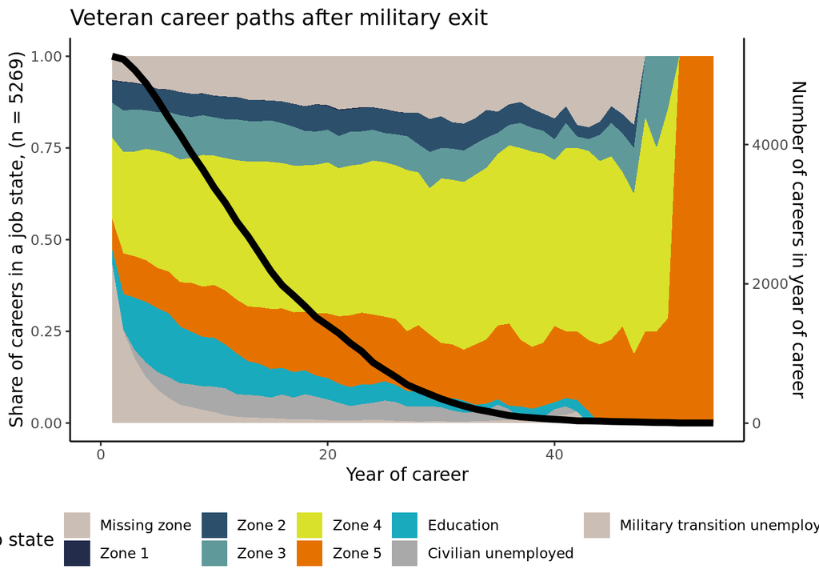

```r
# Plot state frequency over time ---------------

library(scales)
ggplot() +
  geom_area(data = states, aes(x = as.numeric(variable), y = value, fill = state, position = "fill")) +
  geom_line(data = v_states, aes(x = as.numeric(variable), y = v_states/nrow(vet.seq)),
            size = 2) +
  scale_y_continuous(name = paste0("Share of careers in a job state, (n = ", nrow(vet.seq), ")"),
                     sec.axis = sec_axis(trans = ~.*(nrow(vet.seq)), name = "Number of careers in year of career")) +
  xlim(0,ncol(vet.seq)) +
  scale_fill_manual(values = c("#CBBEB5", uva_color_palette[1], uva_color_palette[2],uva_color_palette[4],  uva_color_palette[6], uva_color_palette[9], "#19aabd", "dark gray", "#CBBEB5"), labels = c("Missing zone", "Zone 1", "Zone 2", "Zone 3", "Zone 4", "Zone 5", "Education", "Civilian unemployed", "Military transition unemployed")) +
  xlab("Year of career") +
  labs(title = "Veteran career paths after military exit",
       fill = "Job state") +
  theme_classic() +
  theme(legend.position = "bottom")
```

```r
# Create sequence object for entire veteran careers ------
sts_vet_ten <- bg_vet_job_seq

sts_vet_ten <- as.matrix(sts_vet_ten)
sts_vet_ten <- as.data.frame(sts_vet_ten)

#sts_vet_whole$end_year_a <- as.integer(sts_vet_whole$end_year_a)
#sts_vet_whole$start_year_a <- as.integer(sts_vet_whole$start_year_a)

## CHANGE TO NEW_ZONE
sts_vet_ten <- seqformat(sts_vet_ten, from = "SPELL", to = "STS",
            id = "id",  begin = "start_year", end = "end_year",
            status = "onet_job_zone", process = FALSE, overwrite = FALSE)
```

```
##  [>] time axis: 1 -> 54
```

```
##  [>] converting SPELL data into 5269 STS sequences (internal format)
```

```r
vet.seq <- seqdef(sts_vet_ten, left="DEL", gaps="Civilian unemployment", right="DEL", cpal = c("#CBBEB5", uva_color_palette[1], uva_color_palette[2],uva_color_palette[4],  uva_color_palette[6], uva_color_palette[9], "#19aabd", "#CBBEB5"))
```

```
##  [>] found missing values ('NA') in sequence data
```

```
##  [>] preparing 5269 sequences
```

```
##  [>] coding void elements with '%' and missing values with '*'
```

```
##  [>] 7 distinct states appear in the data:
```

```
##      1 = 0
```

```
##      2 = 1
```

```
##      3 = 2
```

```
##      4 = 3
```

```
##      5 = 4
```

```
##      6 = 5
```

```
##      7 = 6
```

```
##  [>] adding special state(s) to the alphabet: Civilian unemployment
```

```
##  [>] state coding:
```

```
##        [alphabet]            [label]               [long label]
```

```
##      1  0                     0                     0
```

```
##      2  1                     1                     1
```

```
##      3  2                     2                     2
```

```
##      4  3                     3                     3
```

```
##      5  4                     4                     4
```

```
##      6  5                     5                     5
```

```
##      7  6                     6                     6
```

```
##      8  Civilian unemployment Civilian unemployment Civilian unemployment
```

```
##  [>] 5269 sequences in the data set
```

```
##  [>] min/max sequence length: 1/54
```

```r
names(vet.seq) <- paste0(1:ncol(vet.seq))
sts_vet <- vet.seq[, 1:10]

# Tranform data for ggplot ------------

statd <- seqstatd(sts_vet)
states <- statd$Frequencies
states <- as.data.frame(states)
names(states) <- paste0(1:10)
states <- states %>% rownames_to_column(var = "state")
states <- melt(states, id = "state")
v_states <- statd$ValidStates
v_states <- as.data.frame(v_states)
v_states <- v_states %>% rownames_to_column(var = "variable")

meant <- seqmeant(vet.seq)
meant <- as.data.frame(meant)
meant <- meant %>% rownames_to_column(var = "state")

lengths <- seqlength(vet.seq)
lengths <- as.data.frame(lengths)
lengths <- lengths %>% rownames_to_column(var = "id")
length_sum <- quantile(lengths$Length)
length_sum <- as.data.frame(length_sum)
length_sum <- length_sum %>% rownames_to_column(var = "measure")
summary(lengths)
```

```
##       id                Length
##  Length:5269        Min.   : 1.00
##  Class :character   1st Qu.: 6.00
##  Mode  :character   Median :11.00
##                     Mean   :13.03
##                     3rd Qu.:18.00
##                     Max.   :54.00
```

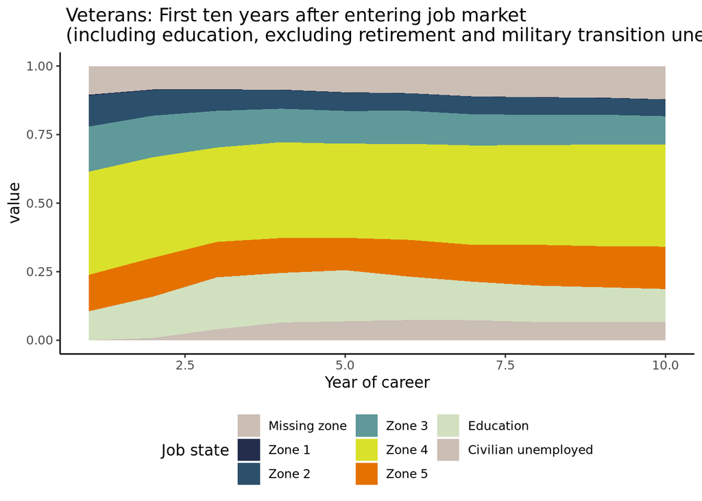

```r
# Plot state frequency over time ---------------

library(scales)
ggplot() +
  geom_area(data = states, aes(x = as.numeric(variable), y = value, fill = state, position = "fill")) +
  xlim(1,10) +
  scale_fill_manual(values = c("#CBBEB5", uva_color_palette[1], uva_color_palette[2],uva_color_palette[4],  uva_color_palette[6], uva_color_palette[9], uva_color_palette[5], "#CBBEB5"), labels = c("Missing zone", "Zone 1", "Zone 2", "Zone 3", "Zone 4", "Zone 5", "Education", "Civilian unemployed")) +
  xlab("Year of career") +
  labs(title = " Veterans: First ten years after entering job market \n (including education, excluding retirement and military transition unemployment)",
       fill = "Job state") +
  theme_classic() +
  theme(legend.position = "bottom") +
  guides(fill = guide_legend(ncol = 3))
```

```r
# Create sequence object for entire veteran careers ------
sts_all_ten <- bg_all_job_seq

sts_all_ten <- as.matrix(sts_all_ten)
sts_all_ten <- as.data.frame(sts_all_ten)

sts_all_ten$end_year_a <- as.integer(sts_all_ten$end_year_a)
sts_all_ten$start_year_a <- as.integer(sts_all_ten$start_year_a)

## CHANGE TO NEW_ZONE
sts_all_ten <- seqformat(sts_all_ten, from = "SPELL", to = "STS",
            id = "id",  begin = "start_year_a", end = "end_year_a",
            status = "onet_job_zone", process = FALSE, overwrite = FALSE)
```

```
##  [>] time axis: 1 -> 119
```

```
##  [>] converting SPELL data into 3862 STS sequences (internal format)
```

```r
all.seq <- seqdef(sts_all_ten, left="DEL", gaps="Civilian unemployment", right="DEL", cpal = c("#CBBEB5", uva_color_palette[1], uva_color_palette[2],uva_color_palette[4],  uva_color_palette[6], uva_color_palette[9], "#19aabd", "#CBBEB5"))
```

```
##  [>] found missing values ('NA') in sequence data
```

```
##  [>] preparing 3862 sequences
```

```
##  [>] coding void elements with '%' and missing values with '*'
```

```
##  [>] 7 distinct states appear in the data:
```

```
##      1 = 0
```

```
##      2 = 1
```

```
##      3 = 2
```

```
##      4 = 3
```

```
##      5 = 4
```

```
##      6 = 5
```

```
##      7 = 6
```

```
##  [>] adding special state(s) to the alphabet: Civilian unemployment
```

```
##  [>] state coding:
```

```
##        [alphabet]            [label]               [long label]
```

```
##      1  0                     0                     0
```

```
##      2  1                     1                     1
```

```
##      3  2                     2                     2
```

```
##      4  3                     3                     3
```

```
##      5  4                     4                     4
```

```
##      6  5                     5                     5
```

```
##      7  6                     6                     6
```

```
##      8  Civilian unemployment Civilian unemployment Civilian unemployment
```

```
##  [>] 3862 sequences in the data set
```

```
##  [>] min/max sequence length: 1/119
```

```r
names(all.seq) <- paste0(1:ncol(all.seq))
sts_all <- all.seq[, 1:10]

# Tranform data for ggplot ------------

statd <- seqstatd(sts_all)
states <- statd$Frequencies
states <- as.data.frame(states)
names(states) <- paste0(1:10)
states <- states %>% rownames_to_column(var = "state")
states <- melt(states, id = "state")
v_states <- statd$ValidStates
v_states <- as.data.frame(v_states)
v_states <- v_states %>% rownames_to_column(var = "variable")

meant <- seqmeant(vet.seq)
meant <- as.data.frame(meant)
meant <- meant %>% rownames_to_column(var = "state")

lengths <- seqlength(vet.seq)
lengths <- as.data.frame(lengths)
lengths <- lengths %>% rownames_to_column(var = "id")
length_sum <- quantile(lengths$Length)
length_sum <- as.data.frame(length_sum)
length_sum <- length_sum %>% rownames_to_column(var = "measure")
summary(lengths)
```

```
##       id                Length
##  Length:5269        Min.   : 1.00
##  Class :character   1st Qu.: 6.00
##  Mode  :character   Median :11.00
##                     Mean   :13.03
##                     3rd Qu.:18.00
##                     Max.   :54.00
```

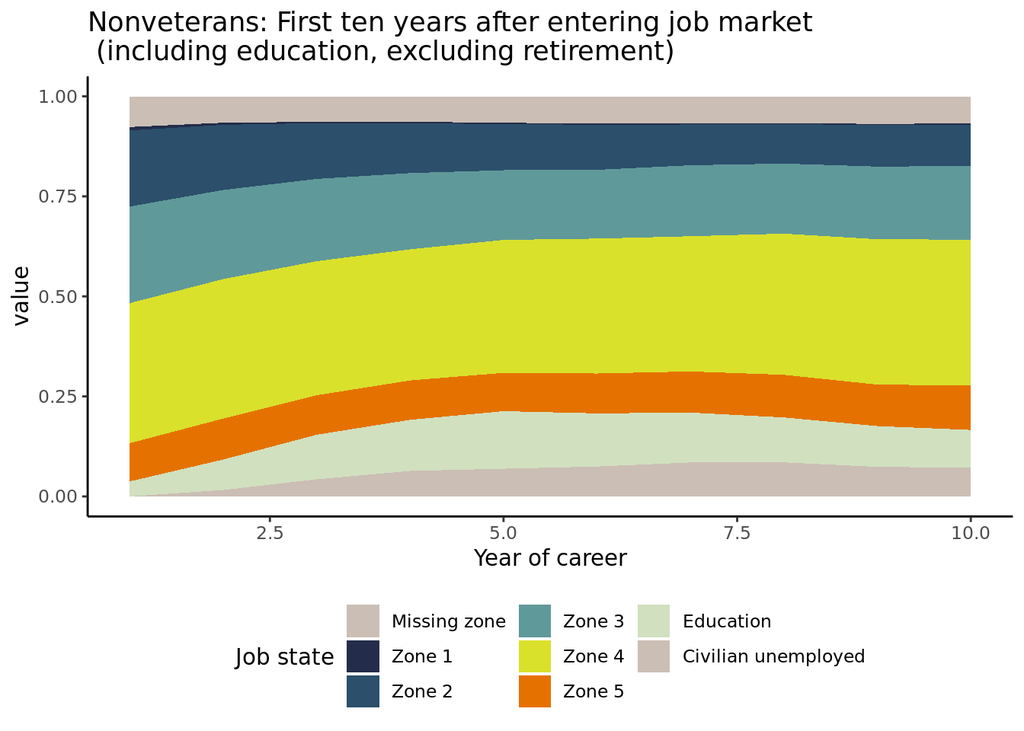

```r
# Plot state frequency over time ---------------

library(scales)
ggplot() +
  geom_area(data = states, aes(x = as.numeric(variable), y = value, fill = state, position = "fill")) +
  xlim(1,10) +
  scale_fill_manual(values = c("#CBBEB5", uva_color_palette[1], uva_color_palette[2],uva_color_palette[4],  uva_color_palette[6], uva_color_palette[9], uva_color_palette[5], "#CBBEB5", "dark gray"), labels = c("Missing zone", "Zone 1", "Zone 2", "Zone 3", "Zone 4", "Zone 5", "Education", "Civilian unemployed",  "Military transition unemployed")) +
  xlab("Year of career") +
  labs(title = "Nonveterans: First ten years after entering job market \n (including education, excluding retirement)",
       fill = "Job state") +
  theme_classic() +
  theme(legend.position = "bottom") +
  guides(fill = guide_legend(ncol = 3))
```

## ASSIGNING MISSING JOB ZONE THE AVERAGE JOB ZONE OF SIMILAR CAREERS

```r
# Create sequence object for entire non-veteran careers ------
sts_vet_whole <- bg_vet_job_seq

sts_vet_whole <- as.matrix(sts_vet_whole)
sts_vet_whole <- as.data.frame(sts_vet_whole)

sts_vet_whole <- seqformat(sts_vet_whole, from = "SPELL", to = "STS",
            id = "id",  begin = "start_year", end = "end_year",
            status = "new_zone", process = FALSE, overwrite = FALSE)
```

```
##  [>] time axis: 1 -> 54
```

```
##  [>] converting SPELL data into 5269 STS sequences (internal format)
```

```r
vet.seq <- seqdef(sts_vet_whole, left="Military transition unemployment", gaps="Civilian unemployment", right="DEL", cpal = c(uva_color_palette[1], uva_color_palette[2],uva_color_palette[4],  uva_color_palette[6], uva_color_palette[9], "#19aabd", "#CBBEB5", "#CBBEB5"))
```

```
##  [>] found missing values ('NA') in sequence data
```

```
##  [>] preparing 5269 sequences
```

```
##  [>] coding void elements with '%' and missing values with '*'
```

```
##  [>] 6 distinct states appear in the data:
```

```
##      1 = 1
```

```
##      2 = 2
```

```
##      3 = 3
```

```
##      4 = 4
```

```
##      5 = 5
```

```
##      6 = 6
```

```
##  [>] adding special state(s) to the alphabet: Military transition unemployment/Civilian unemployment
```

```
##  [>] state coding:
```

```
##        [alphabet]                       [label]                          [long label]
```

```
##      1  1                                1                                1
```

```
##      2  2                                2                                2
```

```
##      3  3                                3                                3
```

```
##      4  4                                4                                4
```

```
##      5  5                                5                                5
```

```
##      6  6                                6                                6
```

```
##      7  Military transition unemployment Military transition unemployment Military transition unemployment
```

```
##      8  Civilian unemployment            Civilian unemployment            Civilian unemployment
```

```
##  [>] 5269 sequences in the data set
```

```
##  [>] min/max sequence length: 1/54
```

```r
names(vet.seq) <- paste0(1:ncol(vet.seq))

# Tranform data for ggplot ------------

statd <- seqstatd(vet.seq)
states <- statd$Frequencies
states <- as.data.frame(states)
names(states) <- paste0(1:ncol(vet.seq))
states <- states %>% rownames_to_column(var = "state")
states <- melt(states, id = "state")
v_states <- statd$ValidStates
v_states <- as.data.frame(v_states)
v_states <- v_states %>% rownames_to_column(var = "variable")

meant <- seqmeant(vet.seq)
meant <- as.data.frame(meant)
meant <- meant %>% rownames_to_column(var = "state")

lengths <- seqlength(vet.seq)
lengths <- as.data.frame(lengths)
lengths <- lengths %>% rownames_to_column(var = "id")
length_sum <- quantile(lengths$Length)
length_sum <- as.data.frame(length_sum)
length_sum <- length_sum %>% rownames_to_column(var = "measure")
summary(lengths)
```

```
##       id                Length
##  Length:5269        Min.   : 1.00
##  Class :character   1st Qu.: 7.00
##  Mode  :character   Median :13.00
##                     Mean   :14.33
##                     3rd Qu.:20.00
##                     Max.   :54.00
```

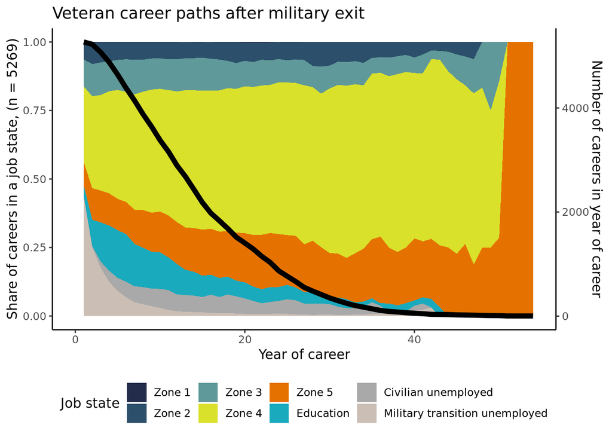

```r
# Plot state frequency over time ---------------

library(scales)
ggplot() +
  geom_area(data = states, aes(x = as.numeric(variable), y = value, fill = state, position = "fill")) +
  geom_line(data = v_states, aes(x = as.numeric(variable), y = v_states/nrow(vet.seq)),
            size = 2) +
  scale_y_continuous(name = paste0("Share of careers in a job state, (n = ", nrow(vet.seq), ")"),
                     sec.axis = sec_axis(trans = ~.*(nrow(vet.seq)), name = "Number of careers in year of career")) +
  xlim(0,ncol(vet.seq)) +
  scale_fill_manual(values = c(uva_color_palette[1], uva_color_palette[2],uva_color_palette[4],  uva_color_palette[6], uva_color_palette[9], "#19aabd", "dark gray", "#CBBEB5"), labels = c("Zone 1", "Zone 2", "Zone 3", "Zone 4", "Zone 5", "Education", "Civilian unemployed", "Military transition unemployed")) +
  xlab("Year of career") +
  labs(title = "Veteran career paths after military exit",
       fill = "Job state") +
  theme_classic() +
  theme(legend.position = "bottom")
```

```r
# Create sequence object for first ten years of veteran careers ------
sts_vet_ten <- bg_vet_job_seq

sts_vet_ten <- as.matrix(sts_vet_ten)
sts_vet_ten <- as.data.frame(sts_vet_ten)

#sts_vet_whole$end_year_a <- as.integer(sts_vet_whole$end_year_a)
#sts_vet_whole$start_year_a <- as.integer(sts_vet_whole$start_year_a)

## CHANGE TO NEW_ZONE
sts_vet_ten <- seqformat(sts_vet_ten, from = "SPELL", to = "STS",
            id = "id",  begin = "start_year", end = "end_year",
            status = "new_zone", process = FALSE, overwrite = FALSE)
```

```
##  [>] time axis: 1 -> 54
```

```
##  [>] converting SPELL data into 5269 STS sequences (internal format)
```

```r
vet.seq <- seqdef(sts_vet_ten, left="DEL", gaps="Civilian unemployment", right="DEL", cpal = c(uva_color_palette[1], uva_color_palette[2],uva_color_palette[4],  uva_color_palette[6], uva_color_palette[9], "#19aabd", "#CBBEB5"))
```

```
##  [>] found missing values ('NA') in sequence data
```

```
##  [>] preparing 5269 sequences
```

```
##  [>] coding void elements with '%' and missing values with '*'
```

```
##  [>] 6 distinct states appear in the data:
```

```
##      1 = 1
```

```
##      2 = 2
```

```
##      3 = 3
```

```
##      4 = 4
```

```
##      5 = 5
```

```
##      6 = 6
```

```
##  [>] adding special state(s) to the alphabet: Civilian unemployment
```

```
##  [>] state coding:
```

```
##        [alphabet]            [label]               [long label]
```

```
##      1  1                     1                     1
```

```
##      2  2                     2                     2
```

```
##      3  3                     3                     3
```

```
##      4  4                     4                     4
```

```
##      5  5                     5                     5
```

```
##      6  6                     6                     6
```

```
##      7  Civilian unemployment Civilian unemployment Civilian unemployment
```

```
##  [>] 5269 sequences in the data set
```

```
##  [>] min/max sequence length: 1/54
```

```r
names(vet.seq) <- paste0(1:ncol(vet.seq))
sts_vet <- vet.seq[, 1:10]

# Tranform data for ggplot ------------

statd <- seqstatd(sts_vet)
states <- statd$Frequencies
states <- as.data.frame(states)
names(states) <- paste0(1:10)
states <- states %>% rownames_to_column(var = "state")
states <- melt(states, id = "state")
v_states <- statd$ValidStates
v_states <- as.data.frame(v_states)
v_states <- v_states %>% rownames_to_column(var = "variable")

meant <- seqmeant(vet.seq)
meant <- as.data.frame(meant)
meant <- meant %>% rownames_to_column(var = "state")

lengths <- seqlength(vet.seq)
lengths <- as.data.frame(lengths)
lengths <- lengths %>% rownames_to_column(var = "id")
length_sum <- quantile(lengths$Length)
length_sum <- as.data.frame(length_sum)
length_sum <- length_sum %>% rownames_to_column(var = "measure")
summary(lengths)
```

```
##       id                Length
##  Length:5269        Min.   : 1.00
##  Class :character   1st Qu.: 6.00
##  Mode  :character   Median :11.00
##                     Mean   :13.03
##                     3rd Qu.:18.00
##                     Max.   :54.00
```

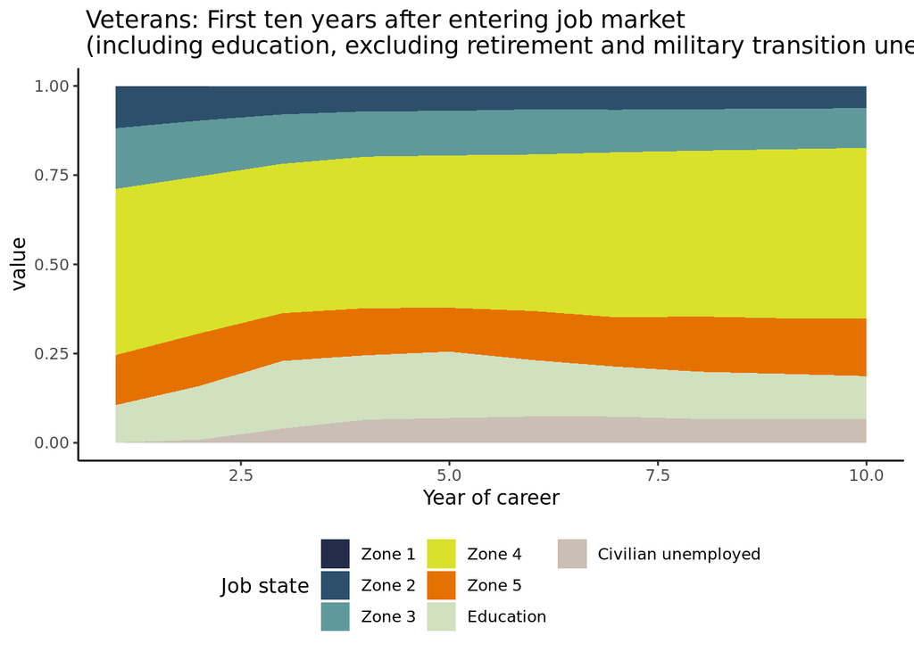

```r
# Plot state frequency over time ---------------

library(scales)
ggplot() +
  geom_area(data = states, aes(x = as.numeric(variable), y = value, fill = state, position = "fill")) +
  xlim(1,10) +
  scale_fill_manual(values = c(uva_color_palette[1], uva_color_palette[2],uva_color_palette[4],  uva_color_palette[6], uva_color_palette[9], uva_color_palette[5], "#CBBEB5"), labels = c("Zone 1", "Zone 2", "Zone 3", "Zone 4", "Zone 5", "Education", "Civilian unemployed")) +
  xlab("Year of career") +
  labs(title = " Veterans: First ten years after entering job market \n (including education, excluding retirement and military transition unemployment)",
       fill = "Job state") +
  theme_classic() +
  theme(legend.position = "bottom") +
  guides(fill = guide_legend(ncol = 3))
```

```r
# Create sequence object for first ten years of nonveterans careers ------
sts_all_ten <- bg_all_job_seq

sts_all_ten <- as.matrix(sts_all_ten)
sts_all_ten <- as.data.frame(sts_all_ten)

sts_all_ten$end_year_a <- as.integer(sts_all_ten$end_year_a)
sts_all_ten$start_year_a <- as.integer(sts_all_ten$start_year_a)

## CHANGE TO NEW_ZONE
sts_all_ten <- seqformat(sts_all_ten, from = "SPELL", to = "STS",
            id = "id",  begin = "start_year_a", end = "end_year_a",
            status = "new_zone", process = FALSE, overwrite = FALSE)
```

```
##  [>] time axis: 1 -> 119
```

```
##  [>] converting SPELL data into 3862 STS sequences (internal format)
```

```r
all.seq <- seqdef(sts_all_ten, left="DEL", gaps="Civilian unemployment", right="DEL", cpal = c(uva_color_palette[1], uva_color_palette[2],uva_color_palette[4],  uva_color_palette[6], uva_color_palette[9], "#19aabd", "#CBBEB5"))
```

```
##  [>] found missing values ('NA') in sequence data
```

```
##  [>] preparing 3862 sequences
```

```
##  [>] coding void elements with '%' and missing values with '*'
```

```
##  [>] 6 distinct states appear in the data:
```

```
##      1 = 1
```

```
##      2 = 2
```

```
##      3 = 3
```

```
##      4 = 4
```

```
##      5 = 5
```

```
##      6 = 6
```

```
##  [>] adding special state(s) to the alphabet: Civilian unemployment
```

```
##  [>] state coding:
```

```
##        [alphabet]            [label]               [long label]
```

```
##      1  1                     1                     1
```

```
##      2  2                     2                     2
```

```
##      3  3                     3                     3
```

```
##      4  4                     4                     4
```

```
##      5  5                     5                     5
```

```
##      6  6                     6                     6
```

```
##      7  Civilian unemployment Civilian unemployment Civilian unemployment
```

```
##  [>] 3862 sequences in the data set
```

```
##  [>] min/max sequence length: 1/119
```

```r
names(all.seq) <- paste0(1:ncol(all.seq))
sts_all <- all.seq[, 1:10]

# Tranform data for ggplot ------------

statd <- seqstatd(sts_all)
states <- statd$Frequencies
states <- as.data.frame(states)
names(states) <- paste0(1:10)
states <- states %>% rownames_to_column(var = "state")
states <- melt(states, id = "state")
v_states <- statd$ValidStates
v_states <- as.data.frame(v_states)
v_states <- v_states %>% rownames_to_column(var = "variable")

meant <- seqmeant(vet.seq)
meant <- as.data.frame(meant)
meant <- meant %>% rownames_to_column(var = "state")

lengths <- seqlength(vet.seq)
lengths <- as.data.frame(lengths)
lengths <- lengths %>% rownames_to_column(var = "id")
length_sum <- quantile(lengths$Length)
length_sum <- as.data.frame(length_sum)
length_sum <- length_sum %>% rownames_to_column(var = "measure")
summary(lengths)
```

```
##       id                Length
##  Length:5269        Min.   : 1.00
##  Class :character   1st Qu.: 6.00
##  Mode  :character   Median :11.00
##                     Mean   :13.03
##                     3rd Qu.:18.00
##                     Max.   :54.00
```

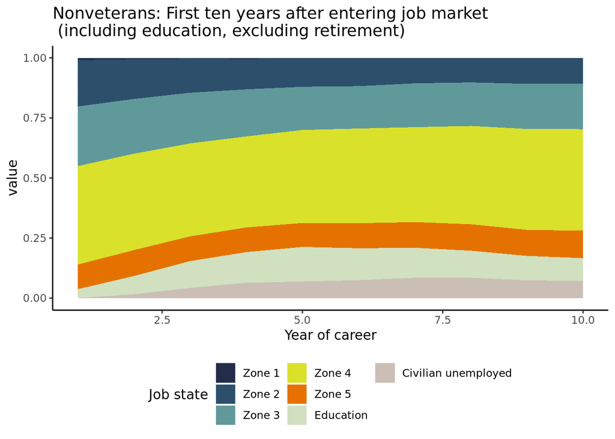

```r
# Plot state frequency over time ---------------

library(scales)
ggplot() +
  geom_area(data = states, aes(x = as.numeric(variable), y = value, fill = state, position = "fill")) +
  xlim(1,10) +
  scale_fill_manual(values = c(uva_color_palette[1], uva_color_palette[2],uva_color_palette[4],  uva_color_palette[6], uva_color_palette[9], uva_color_palette[5], "#CBBEB5"), labels = c("Zone 1", "Zone 2", "Zone 3", "Zone 4", "Zone 5", "Education", "Civilian unemployed")) +
  xlab("Year of career") +
  labs(title = "Nonveterans: First ten years after entering job market \n (including education, excluding retirement)",
       fill = "Job state") +
  theme_classic() +
  theme(legend.position = "bottom") +
  guides(fill = guide_legend(ncol = 3))
```